# Writing Functions

Author

Amy Truong

```python
!pip install palmerpenguins
```

```python
import numpy as np
import pandas as pd
from sys import exit
from palmerpenguins import load_penguins
from plotnine import ggplot, aes, geom_point, geom_bar, labs
```

0. Complete the [**check-in** from Section 6.3.2](https://ds-ml-with-python.github.io/Course-Textbook/05-function_writing.html#nested-environments-and-scope): Write a custom function that does the following:

Limit the penguins dataset to a user-chosen species and/or island. Makes a scatterplot of the penguin bill length and depth. Try writing a version of this function using dynamic lookup, and a version where everything the function needs is passed in directly

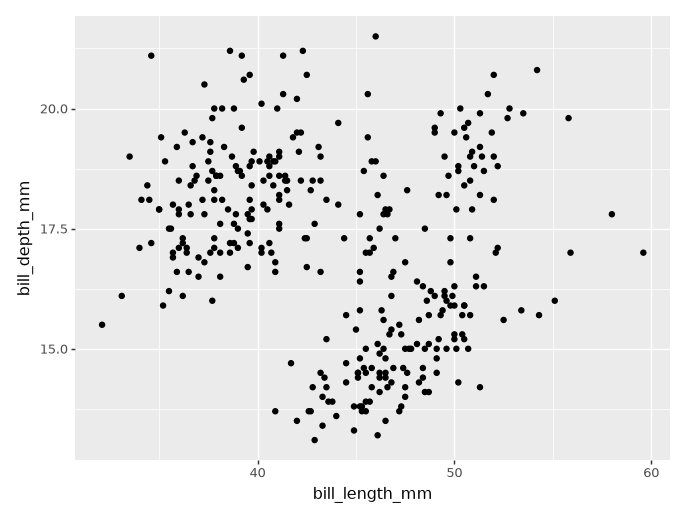

```python
penguins = load_penguins()

def penguin_graph_dynamic(species=None, island=None):
    penguin_subset = penguins

    if species is not None:
        penguin_subset = penguin_subset[
            penguin_subset["species"] == species
        ]

    if island is not None:
        penguin_subset = penguin_subset[
            penguin_subset["island"] == island
        ]

    penguin_subset = penguin_subset.dropna(
        subset=["bill_length_mm", "bill_depth_mm"]
    )

    plot = (
        ggplot(
            penguin_subset,
            aes(x="bill_length_mm", y="bill_depth_mm")
        )
        + geom_point()
    )

    return plot

penguin_graph_dynamic()
```

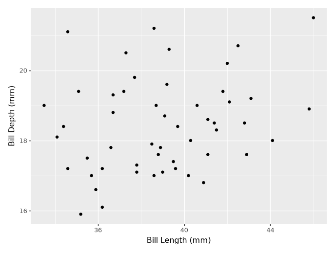

```python
penguins = load_penguins()

def plot_bills_dynamic(species=None, island=None):
    penguin_subset = penguins.copy()

    if species is not None:
        penguin_subset = penguin_subset[
            penguin_subset["species"] == species
        ]

    if island is not None:
        penguin_subset = penguin_subset[
            penguin_subset["island"] == island
        ]

    penguin_subset = penguin_subset.dropna(
        subset=["bill_length_mm", "bill_depth_mm"]
    )

    plot = (
        ggplot(
            penguin_subset,
            aes(x="bill_length_mm", y="bill_depth_mm")
        )
        + geom_point()
        + labs(
            x="Bill Length (mm)",
            y="Bill Depth (mm)"
        )
    )

    return plot

plot_bills_dynamic(species="Adelie", island="Torgersen")
```

1. Fill in the necessary code to write a function called `times_seven()`. The function should take a single argument (`x`) and multiply the input by 7.
- This function should check that the argument is numeric.
- This function should also excitedly announce (print) *“I love sevens!”* if the argument to the function is a 7.

```python
def times_seven(x):
    if not isinstance(x, (int, float)) or isinstance(x, bool):
        exit("The input must be numeric.")

    if x == 7:
        print("I love sevens!")

    return x * 7
```

2. Write and run some *unit tests* for your `times_seven` function. What happens if the input to the function is `[1, 3, 5, 7]`?

It fails the numeric check and exits with the input must be numeric.

```python
assert times_seven(2) == 14
assert times_seven(7) == 49       # Prints "I love sevens!"
assert times_seven(2.5) == 17.5

try:
    times_seven([1, 3, 5, 7])
except SystemExit as error:
    print("List test:", error)
```

```
I love sevens!
List test: The input must be numeric.
```

3. Consider the following function:

```python
def add_or_subtract(first_num, second_num = 2, type = "add"):

  if (type == "add"):
    res = first_num + second_num
  elif (type == "subtract"):
    res = first_num - second_num
  else:
    exit("Please choose `add` or `subtract` as the type.")

    return res
```

**Without running the code**, predict if the following will produce:

1. 1
2. -1
3. 30
4. An error defined by the function `add_or_subtract()`
5. An error defined in a different function, which is called inside the `add_or_subtract()` function

```python
add_or_subtract(5, 6, type = "subtract") #this will print -1

add_or_subtract("orange") #this will produce an error defined in a different function

add_or_subtract(5, 6, type = "multiply") #this will produce an error defined by the function
```

[output not shown]

4. Consider the following code:

```python
first_num  = 5
second_num = 3

result = 8

result = add_or_subtract(first_num, second_num = 4)

result_2 = add_or_subtract(first_num)
```

In your Global Environment, what is the value of…